# HW#3

Lucía Carrera

10/1/2021

```r
knitr::opts_chunk$set(echo = TRUE)

#  load the tidyverse here -- OR-- load dplyr and ggplot2
library(tidyverse)
```

## Question 1: Mapping Aesthetics – 4 pts

#### Variable – Aesthetic

ggplot(data = babies, mapping = aes(x=year, y=totalprop, color=sex)) + geom_line()+ facet_wrap(~ letter)

## Question 2: dplyr

### part a – lists in order 3 pts

```r
# View and Help
# View(msleep)
# help(msleep)

# Method 1
msleep %>% filter(!is.na(awake),!is.na(name)) %>%  arrange(desc(awake)) %>% select(name,awake) %>% head(6)
```

```
## # A tibble: 6 x 2
##   name             awake
##   <chr>            <dbl>
## 1 Giraffe           22.1
## 2 Pilot whale       21.4
## 3 Horse             21.1
## 4 Roe deer          21
## 5 Donkey            20.9
## 6 African elephant  20.7
```

```r
# Method 2
# msleep_nameAwake <- msleep %>% select(name,awake)
# msleep_nameAwake %>% arrange(desc(awake)) %>% head(6)
```

```r
msleep %>% filter(!is.na(awake),!is.na(name)) %>% arrange(awake) %>% select(name,awake) %>% head(6)
```

```
## # A tibble: 6 x 2
##   name                   awake
##   <chr>                  <dbl>
## 1 Little brown bat         4.1
## 2 Big brown bat            4.3
## 3 Thick-tailed opposum     4.6
## 4 Giant armadillo          5.9
## 5 North American Opossum   6
## 6 Long-nosed armadillo     6.6
```

### part b – group_by – 3 pts

```r
mpgby <- msleep %>% group_by(sleep_rem)
msleep %>% group_by(vore) %>% filter(!is.na(vore)) %>%
                  summarise(meanawake = mean(awake),
                  sdawake = sd(awake),
                  n_vore = n())
```

```
## # A tibble: 4 x 4
##   vore    meanawake sdawake n_vore
##   <chr>       <dbl>   <dbl>  <int>
## 1 carni       13.6     4.68     19
## 2 herbi       14.5     4.88     32
## 3 insecti      9.06    5.92      5
## 4 omni        13.1     2.95     20
```

## Question 3

### part a – bar graph – 3 pts

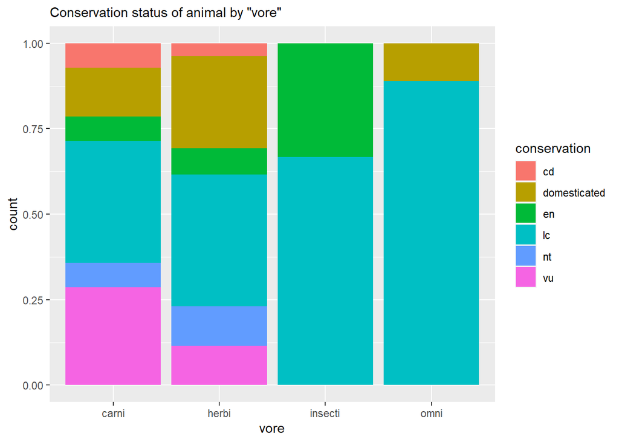

```r
vores_nona <- msleep %>% filter(!is.na(conservation), !is.na(vore))

ggplot(data = vores_nona,
       mapping = aes( x = vore, fill = conservation)) +
    geom_bar(position = 'fill') +
    labs(subtitle = 'Conservation status of animal by "vore"')
```

### part b – box plot – 3 pts

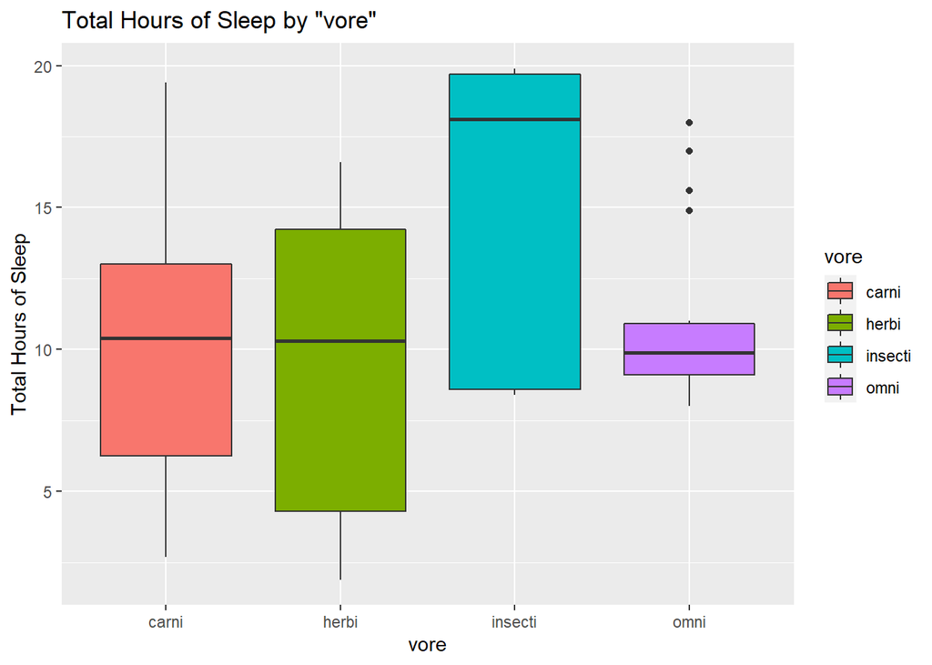

```r
msleep %>% filter(!is.na(vore)) %>%
  ggplot(mapping = aes(x = vore, y = sleep_total, fill = vore)) +
  geom_boxplot() +
  labs( title = 'Total Hours of Sleep by "vore"', y = 'Total Hours of Sleep')
```

### part c – facets – 3 pts

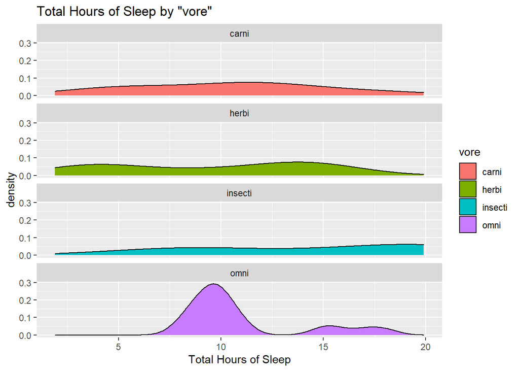

```r
msleep %>% filter(!is.na(vore)) %>%
  ggplot(mapping = aes(x = sleep_total, fill = vore)) +
  geom_density() +
  labs( title = 'Total Hours of Sleep by "vore"', x = 'Total Hours of Sleep') +
  facet_wrap(~ vore, ncol = 1)
```

### part d – logtrans – 3 pts

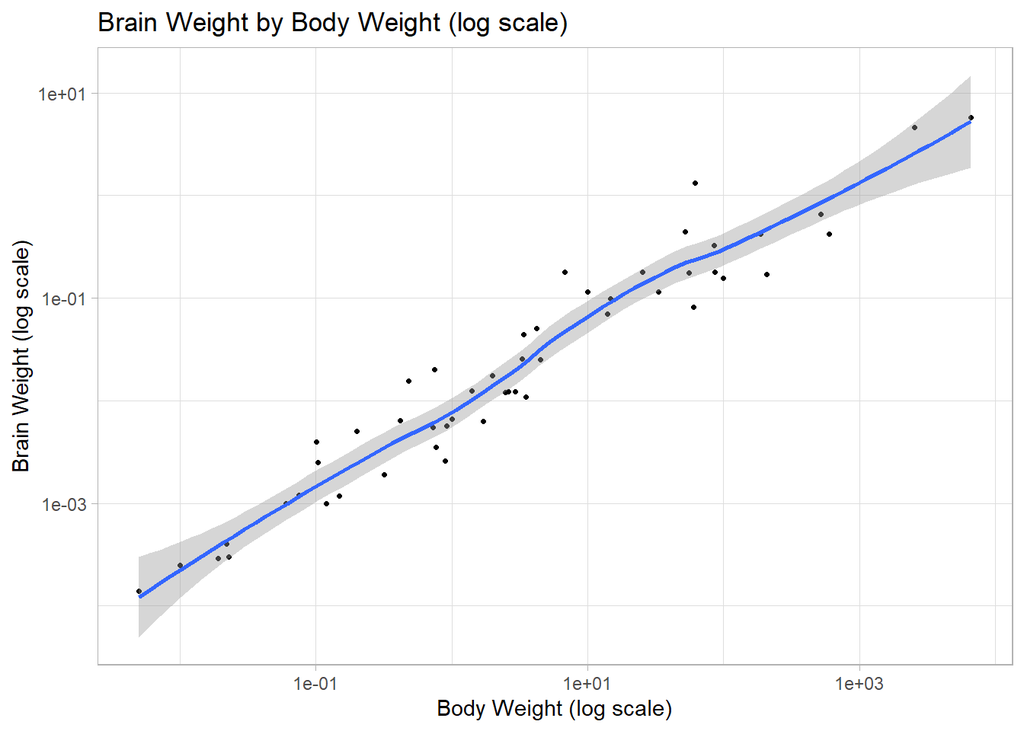

```r
msleep %>% filter(!is.na(vore)) %>%
  ggplot(mapping = aes(x = bodywt, y=brainwt)) +
  geom_point(size=.9) +
  geom_smooth() +
  scale_x_log10() +
  scale_y_log10() +
  labs( title = 'Brain Weight by Body Weight (log scale)', x = 'Body Weight (log scale)', y = 'Brain Weight (log scale)') +
  theme_light()
```

### part e – whylog – 4 pts

<why is the log transformation useful? Put answer here > The log transformation is used when our original data does not follow the bell curve. With this mathematical tool we can transform the data so that its base is not as skewed. If we observe the graph below, most of the points are in the left and then the gray region occupies a large part of the graph. This is due to the data being skewed.

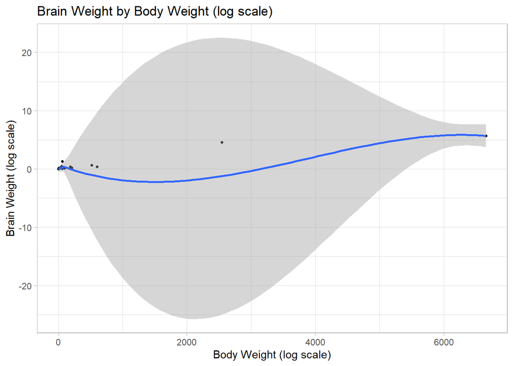

```r
#  Graph here the same scatterplot without the log transformation
msleep %>% filter(!is.na(vore)) %>%
  ggplot(mapping = aes(x = bodywt, y=brainwt)) +
  geom_point(size=.9) +
  geom_smooth() +
  labs( title = 'Brain Weight by Body Weight (log scale)', x = 'Body Weight (log scale)', y = 'Brain Weight (log scale)') +
  theme_light()
```

## Question 4: Lie Factor – 4 pts

[output not shown]

#### Formula

LIE_effect = SIZE_effect_graphic / SIZE_effect_data SIZE = ( VALUE_one - VALUE_two ) / VALUE_two

#### Comparison (Barry Bonds and Babe Ruth bar):

SIZE_effect_graphic = (( 7.2 - 2.4 ) / 2.4 ) * 100 = 200% SIZE_effect_data = (( 762 - 714 ) / 714 ) * 100 = 6.72%

LIE_effect = 200 / 6.72 = 29.76

#### Conclusion

The Lie effect of this graph is not in range according to Tufte (0.95 to 1.05). In fact, it is very much over the desired number, meaning that the graph presented overstates the effect in the data. The bargraph is not directly proportional to the numerical data, hence we should not be making conclusions of the data collected according to it. Without making calculations, one could see that there is a potential problem by seeing that it does not commence in zero but instead at 690. If the entire y axis had been shown we would have seen that there is very little difference between each bar.